# clean_merge_allFollowups

Bernice Cheung

7/6/2021

# Import all data

import baseline data

```r
# import baseline data (after screening)
baselineDf <- read.csv(here("Baseline", "Inputs", "wideDf.csv"))

# import subject paring data
pairDf <- read.csv(here("TimeSeries", "Inputs", "subPairing.csv"))
```

import all three follow-up data (remove the two header lines)

```r
# F1:
# load raw data
rawDf <- read.csv(here("Raw_data", "Goal Longitudinal_F1_May 5, 2021_13.45.csv"), stringsAsFactors = F)

rawDf_cleaned <- rawDf[-c(1,2),] %>% # delete the first two rows of labels and questions
  rename(PA1_F1_1 = PA1_F1_1_1, PC1_F1_1 = PC1_F1_1_1, PB1_F1_1 = PB1_F1_1_1,  # rename progress variables
         PA1_F1_2 = PA1_F1_2_1, PC1_F1_2 = PC1_F1_2_1, PC3_F1_2 = PC3_F1_1.1, PB1_F1_2 = PB1_F1_2_1,
         PA1_F1_3 = PA1_F1_3_1, PC1_F1_3 = PC1_F1_3_1, PB1_F1_3 = PB1_F1_3_1,
         PA1_F1_4 = PA1_F1_4_1, PC1_F1_4 = PC1_F1_4_1, PB1_F1_4 = PB1_F1_4_1,
         PA1_F1_5 =PA1_F1_5_1, PC1_F1_5 = PC1_F1_5_1, PB1_F1_5 = PB1_F1_5_1,
         plan_F1_4 = plan_F4_4, adjustTime_F1_2 = adjustTime_F1_1.1, goalType_F1_4N = goalType_F1_4) %>% # correct a typo
  mutate(across(starts_with("status"), ~ recode(.x, `1` = "continued", # recode status
                                               `2` = "completed",
                                               `3` = "abandoned",
                                               `4` = "adjusted")))


# write the data without the 2 rows
write.csv(rawDf_cleaned, here("Followups", "Inputs", "raw_F1_clean.csv"), row.names = F)

# reload the raw cleaned dataframe
F1Df <- read.csv(here("Followups", "Inputs", "raw_F1_clean.csv"),stringsAsFactors = F)

# F2:
# load raw data
rawDf <- read.csv(here("Raw_data", "Goal Longitudinal_F2_June 18, 2021_02.12.csv"), stringsAsFactors = F)

# delete the first two rows of labels and questions
rawDf_cleaned <- rawDf[-c(1,2),] %>%
  rename(PA1_F2_1 = PA1_F2_1_1, PC1_F2_1 = PC1_F2_1_1, PB1_F2_1 = PB1_F2_1_1,  # rename progress variables
         PA1_F2_2 = PA1_F2_2_1, PC1_F2_2 = PC1_F2_2_1, PC3_F2_2 = PC3_F2_1.1, PB1_F2_2 = PB1_F2_2_1,
         PA1_F2_3 = PA1_F2_3_1, PC1_F2_3 = PC1_F2_3_1, PB1_F2_3 = PB1_F2_3_1,
         PA1_F2_4 = PA1_F2_4_1, PC1_F2_4 = PC1_F2_4_1, PB1_F2_4 = PB1_F2_4_1,
         PA1_F2_5 =PA1_F2_5_1, PC1_F2_5 = PC1_F2_5_1, PB1_F2_5 = PB1_F2_5_1,
         plan_F2_4 = plan_F4_4, adjustTime_F2_2 = adjustTime_F2_1.1, goalType_F2_4N = goalType_F2_4) %>% # correct a typo
  mutate(across(starts_with("status"), ~ recode(.x, `1` = "continued", # recode status
                                               `2` = "completed",
                                               `3` = "abandoned",
                                               `4` = "adjusted")))

# write the data without the 2 rows
write.csv(rawDf_cleaned, here("Followups", "Inputs", "raw_F2_clean.csv"), row.names = F)

# reload the raw cleaned dataframe
F2Df <- read.csv(here("Followups", "Inputs", "raw_F2_clean.csv"),stringsAsFactors = F)

# F3:
# load raw data
rawDf <- read.csv(here("Raw_data", "Goal Longitudinal_F3_relabeled2_July 6, 2021_11.50.csv"), stringsAsFactors = F)

# delete the first two rows of labels and questions
rawDf_cleaned <- rawDf[-c(1,2),] %>%
  rename(PA1_F3_1 = PA1_F3_1_1, PC1_F3_1 = PC1_F3_1_1, PB1_F3_1 = PB1_F3_1_1,  # rename progress variables
         PA1_F3_2 = PA1_F3_2_1, PC1_F3_2 = PC1_F3_2_1, PC3_F3_2 = PC3_F3_1.1, PB1_F3_2 = PB1_F3_2_1,
         PA1_F3_3 = PA1_F3_3_1, PC1_F3_3 = PC1_F3_3_1, PB1_F3_3 = PB1_F3_3_1,
         PA1_F3_4 = PA1_F3_4_1, PC1_F3_4 = PC1_F3_4_1, PB1_F3_4 = PB1_F3_4_1,
         PA1_F3_5 = PA1_F3_5_1, PC1_F3_5 = PC1_F3_5_1, PB1_F3_5 = PB1_F3_5_1,
         plan_F3_4 = plan_F4_4, adjustTime_F3_2 = adjustTime_F3_1.1, goalType_F3_4N = goalType_F3_4) %>% # correct a typo
  mutate(across(starts_with("status"), ~ recode(.x, `1` = "continued", # recode status
                                               `2` = "completed",
                                               `3` = "abandoned",
                                               `4` = "adjusted")))

# write the data without the 2 rows
write.csv(rawDf_cleaned, here("Followups", "Inputs", "raw_F3_clean.csv"), row.names = F)

# reload the raw cleaned dataframe
F3Df <- read.csv(here("Followups", "Inputs", "raw_F3_clean.csv"),stringsAsFactors = F)
```

# Initiate a summary dataframe

generate a summary Df from the baseline data

```r
summaryDf <- pairDf %>%
  left_join(baselineDf, by = c("AmazonIdentifier" = "MTurkCode")) %>%
  mutate(baseline_complete = ifelse(is.na(Finished), FALSE, TRUE)) %>%
  select("MTurkCode" = AmazonIdentifier, baseline_complete, listNum, contains("Type")) %>%
  mutate(across(c(goalType_1: goalType_5), ~ recode(.x, `1` = "short-term",
                                               `2` = "long-term",
                                               `3` = "recurrance")))
```

# Screen % clean follow-up datasets

## Screen Follow-up 1:

### Check duration:

21 participants took less than 5 minutes to complete the first follow-up survey; all of them were continuing pursing their baseline goals.

```r
F1Df$duration <- F1Df$Duration..in.seconds./60

# check durations
describe(F1Df$duration)
```

```
##    vars   n  mean    sd median trimmed  mad min   max range skew kurtosis   se
## X1    1 223 14.98 12.66   11.1   12.68 7.12 1.4 84.38 82.98 2.74     9.78 0.85
```

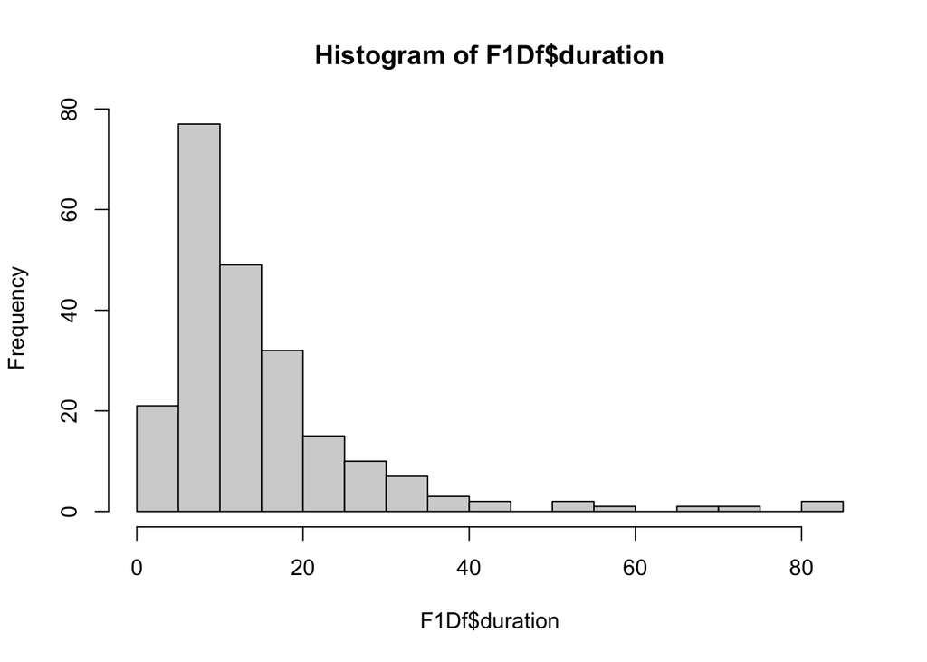

```r
hist(F1Df$duration, 20)
```

```r
# check subjects who completed within 5 minutes
durationDf <- summaryDf %>%
  left_join(F1Df, by = c("MTurkCode" = "workerId")) %>%
  select(MTurkCode, listNum, duration, contains("status_")) %>%
  arrange(duration) %>%
  filter(duration < 5)

duration_id <- durationDf$MTurkCode
```

### check missing data

```r
# select and modify variables only relevant to follow-up progress
F1Df_progress <- F1Df %>%
  left_join(baselineDf, by = c("workerId" = "MTurkCode")) %>%
  rename(MTurkCode = workerId) %>%
  filter(is.na(listNum) == FALSE) %>% # filter out subjects who didn't pass baseline screening
  select(starts_with("status_"),starts_with("ACRISS"),starts_with("commitment"),starts_with("urgency"),starts_with("effort"),starts_with("AR"), # select goal progress relevant variables
        starts_with("resources"),starts_with("plan"),paste0("PA1_F1_", 1:5),paste0("PA3_F1_", 1:5),paste0("PB1_F1_", 1:5),paste0("PB3_F1_", 1:5),paste0("PC1_F1_", 1:5),paste0("PC3_F1_", 1:5), starts_with("goalType_"), MTurkCode, listNum) %>%
  select(-starts_with("goalType_F1")) %>%
  rowwise() %>%
  mutate(progress_F1_1 = case_when( # extract the corresponding progress and satisfaction ratings based on goal types
    goalType_1 == 1 ~ PA1_F1_1,
    goalType_1 == 2 ~ PB1_F1_1,
    goalType_1 == 3 ~ PC1_F1_1),
    progress_F1_2 = case_when(
    goalType_2 == 1 ~ PA1_F1_2,
    goalType_2 == 2 ~ PB1_F1_2,
    goalType_2 == 3 ~ PC1_F1_2),
    progress_F1_3 = case_when(
    goalType_3 == 1 ~ PA1_F1_3,
    goalType_3 == 2 ~ PB1_F1_3,
    goalType_3 == 3 ~ PC1_F1_3),
    progress_F1_4 = case_when(
    goalType_4 == 1 ~ PA1_F1_4,
    goalType_4 == 2 ~ PB1_F1_4,
    goalType_4 == 3 ~ PC1_F1_4),
    progress_F1_5 = case_when(
    goalType_5 == 1 ~ PA1_F1_5,
    goalType_5 == 2 ~ PB1_F1_5,
    goalType_5 == 3 ~ PC1_F1_5),
    satisfaction_F1_1 = case_when(
    goalType_1 == 1 ~ PA3_F1_1,
    goalType_1 == 2 ~ PB3_F1_1,
    goalType_1 == 3 ~ PC3_F1_1),
    satisfaction_F1_2 = case_when(
    goalType_2 == 1 ~ PA3_F1_2,
    goalType_2 == 2 ~ PB3_F1_2,
    goalType_2 == 3 ~ PC3_F1_2),
    satisfaction_F1_3 = case_when(
    goalType_3 == 1 ~ PA3_F1_3,
    goalType_3 == 2 ~ PB3_F1_3,
    goalType_3 == 3 ~ PC3_F1_3),
    satisfaction_F1_4 = case_when(
    goalType_4 == 1 ~ PA3_F1_4,
    goalType_4 == 2 ~ PB3_F1_4,
    goalType_4 == 3 ~ PC3_F1_4),
    satisfaction_F1_5 = case_when(
    goalType_5 == 1 ~ PA3_F1_5,
    goalType_5 == 2 ~ PB3_F1_5,
    goalType_5 == 3 ~ PC3_F1_5)
    ) %>%
  select(-paste0("PA1_F1_", 1:5),-paste0("PA3_F1_", 1:5),-paste0("PB1_F1_", 1:5),-paste0("PB3_F1_", 1:5),-paste0("PC1_F1_", 1:5),-paste0("PC3_F1_", 1:5))

# transform the progress rating df into a long format
F1Df_progress_long <- F1Df_progress %>%
  gather(variable, rating, c(status_F1_1: plan_F1_5, goalType_1: goalType_5, progress_F1_1: satisfaction_F1_5)) %>%
  rowwise() %>%
  mutate(goal = case_when( # generated the corresponding goal number from the variable name
    str_detect(variable, "goalType") ~ str_split_fixed(variable, "_", n = 4)[2],
    str_detect(variable, "resources") ~ str_split_fixed(variable, "_", n = 4)[4],
    TRUE ~ str_split_fixed(variable, "_", n = 4)[3])) %>%
  filter(goal <= listNum) # only include the ratings corresponding to the goals they listed at baseline



# calculate the percentage of missing data
F1Df_progress_long %>%
  group_by(MTurkCode) %>%
  summarise(missNum = sum(is.na(rating)),
            totalNum = mean(listNum) * 17,
            missPerc = ((missNum/totalNum) * 100)) %>%
  arrange(desc(missPerc)) %>%
  head(10)
```

```
## # A tibble: 10 x 4
##    MTurkCode      missNum totalNum missPerc
##    <chr>            <int>    <dbl>    <dbl>
##  1 A13FUEPWBCLBUY       1       34     2.94
##  2 A1ROEDVMTO9Y3X       1       34     2.94
##  3 AMTTB8JUWRRM7        1       34     2.94
##  4 A1IBLFQ2E6VA2J       2       85     2.35
##  5 A2SFFO79KSG5VA       2       85     2.35
##  6 A1D2ZSPIHOI23K       1       51     1.96
##  7 A3CAF7LTD3ORSG       1       51     1.96
##  8 A3HXM7BGH18FOW       1       51     1.96
##  9 A22SZHZTF72TRM       1       68     1.47
## 10 A1BWS5AD2T4NIR       1       85     1.18
```

### check repetitive response

3 participants provided repetitive response for more than 10 questions in a row

```r
# extract columns with self-report ratings
F1Df_progress_rating <- F1Df_progress %>%
  select(-c("MTurkCode", "listNum",starts_with("status_"), starts_with("goalType")))

# extract the max number of repetitive response in a row
variation <- apply(F1Df_progress_rating,1,function(x) rle(x))
variation.length <-unlist(lapply(variation,function(x) max(x$lengths)))
describe(variation.length)
```

```
##    vars   n mean   sd median trimmed  mad min max range skew kurtosis   se
## X1    1 220 4.02 2.48      4     3.7 1.48   1  30    29 5.89    54.34 0.17
```

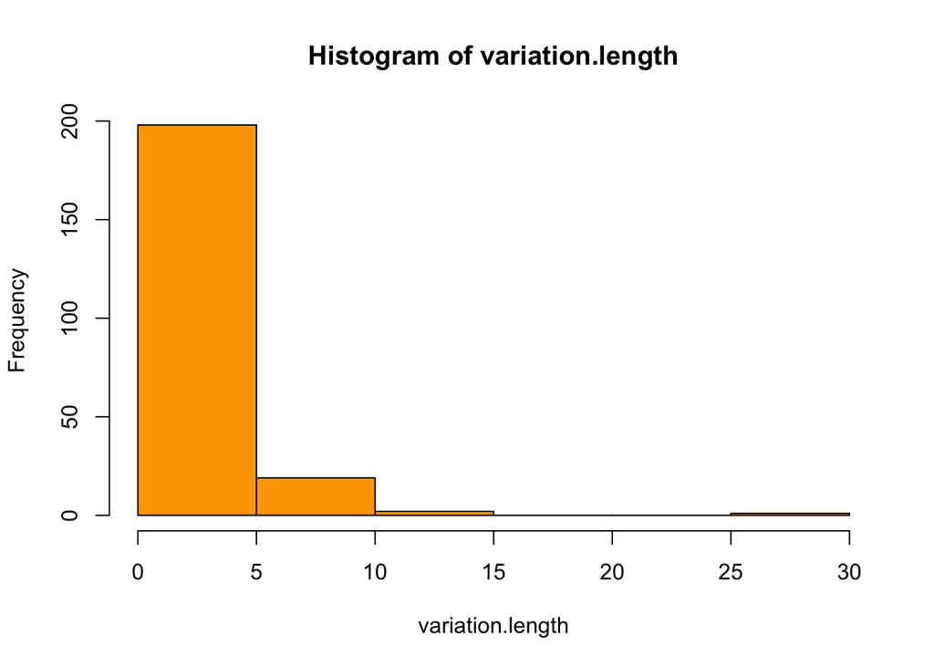

```r
hist(variation.length, col = c(rep("orange", 2)))
```

```r
F1Df_progress$invariance_max <- variation.length

# extract subject id who has more than 20 repetitive response in a row
id_invariance <- F1Df_progress$MTurkCode[variation.length > 10]
```

### F1 Data screening summary

There’s no overlap between subjects who had really short duration and how had a large number of repetitive response. So, at this stage I would not screening out any subjects based on these criteira, but I’m going to mark them in the summary sheet.

```r
# select variables relevant to screening
F1_screenSum <- F1Df %>%
  rename(MTurkCode = workerId) %>%
  left_join(F1Df_progress[,c("MTurkCode", "invariance_max", "listNum")], by = "MTurkCode") %>%
  select(MTurkCode, listNum, starts_with("status_"),duration, invariance_max)

# sort by duration
F1_screenSum %>%
  arrange(duration) %>%
  head(10)
```

```
##         MTurkCode listNum status_F1_1 status_F1_2 status_F1_3 status_F1_4
## 1  A3UUH3632AI3ZX       1   continued
## 2  A1CTUG0RUGCY48       1   continued
## 3  A1D2ZSPIHOI23K       3   continued   continued   continued
## 4  A1D7IULWFI8PB1       3   continued   continued   continued
## 5   AWVLT2L5AP873       3   continued   continued   continued
## 6  A1H5Q9HRH4RPZU       3   continued   continued   continued
## 7  A1DD23J1WBGQUU       3   continued   continued   continued
## 8  A3AJJHOAV7WIUQ       3   continued   continued   continued
## 9  A1WS9UHL45VZ0X       3   continued   continued   continued
## 10 A1ZT30BGR3266K       2   continued   continued
##    status_F1_5 duration invariance_max
## 1              1.400000              2
## 2              2.100000              4
## 3              2.683333              3
## 4              3.216667              3
## 5              3.433333              5
## 6              3.616667              2
## 7              3.900000              4
## 8              3.916667              4
## 9              3.950000              3
## 10             3.983333              5
```

```r
# sort by invariance_max
F1_screenSum %>%
  arrange(desc(invariance_max)) %>%
  head(10)
```

```
##         MTurkCode listNum status_F1_1 status_F1_2 status_F1_3 status_F1_4
## 1   AHKRGPN5D3I2G       5   continued   continued   completed   continued
## 2   AXF0OX50YZQC6       5   continued   continued   continued   continued
## 3  A2IJEKMVEHQ90W       5   continued   continued   continued   continued
## 4  A3ROYUO9LWA22S       5   completed   continued   continued   continued
## 5  A38DHLB88V8DL8       4   continued   continued   continued   continued
## 6  A1ZT0TLZZTT47M       5   continued   continued   continued   continued
## 7  A1W850QN9RK019       5   continued   continued   continued   continued
## 8  A19YQU3ZZ8USPO       3    adjusted   completed   continued
## 9  A1WQACYPLESVGL       5   continued   continued   continued   completed
## 10  A21ZYTE6WOKUA       4   abandoned   completed   continued   continued
##    status_F1_5  duration invariance_max
## 1    continued 25.666667             30
## 2    continued 14.250000             15
## 3    completed  9.016667             12
## 4    continued 73.766667             10
## 5              10.883333              9
## 6    continued 10.783333              9
## 7    continued 32.950000              8
## 8              18.033333              8
## 9    continued 33.866667              8
## 10             41.066667              7
```

```r
# flag participants who has duration < 5 or repetitive response > 10
F1_screenSum <- F1_screenSum %>%
  mutate(F1_screen_Flag = case_when(
    duration < 5 ~ TRUE,
    invariance_max > 10 ~ TRUE,
    TRUE ~ FALSE
  ),
  F1_include = case_when( # would not include subject who were screened out at baseline
    is.na(listNum) == TRUE ~ FALSE,
    TRUE ~ TRUE
  ))
```

### Merge the summary data

```r
# merge summary data
summaryDf_F1 <- summaryDf %>%
  left_join(select(F1Df, c(starts_with("status_"), workerId, Finished)), by = c("MTurkCode" = "workerId")) %>%
  left_join(select(F1_screenSum, c(F1_screen_Flag, F1_include, MTurkCode)), by = "MTurkCode") %>%
  rename(F1_complete = Finished) %>%
  mutate(F1_complete = recode(F1_complete, `1` = TRUE)) %>%
  mutate(F1_complete = replace_na(F1_complete, FALSE))
```

## Clean Follow-up 1 datasets

A clean dataset for the progress ratings for goals listed at baseline

```r
F1_progress_base <- F1Df_progress_long %>%
  rowwise() %>%
  mutate(variable = case_when(
    str_detect(variable, "ACRISS") ~ paste0(substr(variable, 1,9), substr(variable,12,13)),
    TRUE ~ str_sub(variable, 1, nchar(variable)-2))) %>%
  spread (variable, rating)
```

A goal representation dataset for goals that are achieved or abandoned.

```r
# filter out goals that are achieved or abandoned
F1_terminateGoals <- F1_progress_base %>%
  select(MTurkCode, goal, status_F1, listNum) %>%
  rename(status = status_F1) %>%
  filter(status == "completed" | status == "abandoned") %>%
  mutate(F1_terminate = TRUE,
         terminate_time = "F1")

# transform the goal rep dataset into a long format
F1_goalRep_long <- F1Df %>%
  select(workerId, starts_with("G")) %>%
  select(-starts_with("goal")) %>%
  select(-c(G30_3, G30_4, G30_5)) %>%
  pivot_longer(
    cols = starts_with("G"),
    names_to = c("variable", "time_point", "goal"),
    values_to = "rating",
    names_prefix = "G",
    names_sep = "_"
  ) %>%
  mutate(variable = as.numeric(variable)) %>%
  filter(variable < 32) %>%
  arrange(workerId, variable)# exclude variables corresponding to the progress rating for new goals

# replace the variable numbers with the variable names
variableName <- c("construal_level", "temporal_duration", "frequency", "specificity", "end_state_specificity", "approach_avoidance", "attainment_maintenance", "measurability", "importance", "meaningfulness", "instrumentality", "connectedness", "attractiveness_achievement", "attractiveness_progress", "social_desirability", "difficulty", "affordance", "attainability", "clarity", "control", "external_motivation", "introjected_motivation", "identified_motivation", "intrinsic_motivation", "ought_motivation", "ideal_motivation", "basic_needs", "commonality", "visibility", "external_importance", "conflict")

replaceName <- rep(rep(variableName, each = 5), length(unique(F1_goalRep_long$workerId))) # repeat the name list for all five goals for each subject

F1_goalRep_long$variable <- replaceName

# transform the goal rep dataset into a wide format
F1_goalRep_wide <- F1_goalRep_long %>%
  spread (variable, rating)

# merge with the terminated goal dataset
F1_goalRep_post_w <- F1_terminateGoals %>%
  left_join(F1_goalRep_wide, by = c("MTurkCode" = "workerId", "goal")) %>%
  select(-F1_terminate)

# transform the wide format into a long format
F1_goalRep_post_l <- F1_goalRep_post_w %>%
  gather(affordance: visibility, key = "variable", value = "post_rating")
```

A goal representation dataset for goals that are adjusted

```r
# filter out goals that are adjusted
F1_adjustGoals <- F1_progress_base %>%
  select(MTurkCode, goal, status_F1, listNum) %>%
  filter(status_F1 == "adjusted") %>%
  mutate(F1_adjust = TRUE)

# transform the goal rep dataset into a long format (including goal progress)
F1_goalRep_long_aj <- F1Df %>%
  select(workerId, starts_with("G")) %>%
  select(-starts_with("goal")) %>%
  select(-c(G30_3, G30_4, G30_5)) %>%
  pivot_longer(
    cols = starts_with("G"),
    names_to = c("variable", "time_point", "goal"),
    values_to = "rating",
    names_prefix = "G",
    names_sep = "_"
  ) %>%
  mutate(variable = as.numeric(variable)) %>%
  arrange(workerId, variable)

# add the variables pertaining to progress
variableName_progress <- c(variableName, c("commitment", "urgency", "effort", "initial_time", "regret", "procrastination", "failure", "self_resources", "other_resources", "implementation_intention"))

replaceName <- rep(rep(variableName_progress, each = 5), length(unique(F1_goalRep_long_aj$workerId))) # repeat the name list for all five goals for each subject

F1_goalRep_long_aj$variable <- replaceName

# transform the goal rep dataset into a wide format
F1_goalRep_wide_aj<- F1_goalRep_long_aj %>%
  spread (variable, rating)

# merge with the adjusted goal dataset
F1_goalRep_adjust_w <- F1_adjustGoals %>%
  left_join(F1_goalRep_wide_aj, by = c("MTurkCode" = "workerId", "goal")) %>%
  rename(status = status_F1) %>%
  select(-F1_adjust)

# transform the wide format into a long format
F1_goalRep_adjust_l <- F1_goalRep_adjust_w %>%
  gather(affordance: visibility, key = "variable", value = "adjustBase_rating")
```

## Screen follow-up 2:

### Check duration:

35 participants took less than 5 minutes to complete the first follow-up survey; all of them were continuing pursing their baseline goals; The participants who had the shortest duration didn’t provide any ratings (both of his/her goals have been terminated at F1 (either completed or abandoned)).

```r
F2Df$duration <- F2Df$Duration..in.seconds./60

# check durations
describe(F2Df$duration)
```

```
##    vars   n  mean   sd median trimmed  mad  min   max range skew kurtosis   se
## X1    1 208 12.81 9.97    9.8   11.15 6.78 0.87 63.27  62.4 2.08     5.63 0.69
```

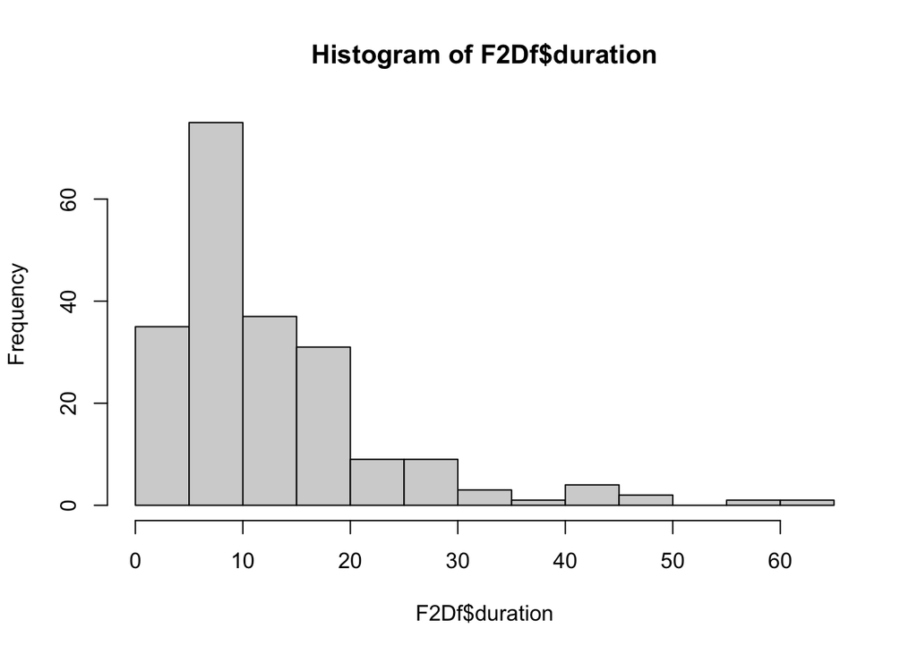

```r
hist(F2Df$duration, 20)
```

```r
# check subjects who completed within 5 minutes
durationDf <- summaryDf %>%
  left_join(F2Df, by = c("MTurkCode" = "workerId")) %>%
  select(MTurkCode, listNum, duration, contains("status_")) %>%
  arrange(duration) %>%
  filter(duration < 5)

duration_id <- durationDf$MTurkCode
```

### check missing data

Among participants who have missing data, most of them missed one question; 7 missed two questions

```r
# select and modify variables only relevant to follow-up progress
F2Df_progress <- F2Df %>%
  left_join(baselineDf, by = c("workerId" = "MTurkCode")) %>%
  rename(MTurkCode = workerId) %>%
  filter(is.na(listNum) == FALSE) %>% # filter out subjects who didn't pass baseline screening
  select(starts_with("status_"),starts_with("ACRISS"),starts_with("commitment"),starts_with("urgency"),starts_with("effort"),starts_with("AR"), # select goal progress relevant variables
        starts_with("resources"),starts_with("plan"),paste0("PA1_F2_", 1:5),paste0("PA3_F2_", 1:5),paste0("PB1_F2_", 1:5),paste0("PB3_F2_", 1:5),paste0("PC1_F2_", 1:5),paste0("PC3_F2_", 1:5), starts_with("goalType_"), MTurkCode, listNum) %>%
  select(-starts_with("goalType_F2")) %>%
  rowwise() %>%
  mutate(progress_F2_1 = case_when( # extract the corresponding progress and satisfaction ratings based on goal types
    goalType_1 == 1 ~ PA1_F2_1,
    goalType_1 == 2 ~ PB1_F2_1,
    goalType_1 == 3 ~ PC1_F2_1),
    progress_F2_2 = case_when(
    goalType_2 == 1 ~ PA1_F2_2,
    goalType_2 == 2 ~ PB1_F2_2,
    goalType_2 == 3 ~ PC1_F2_2),
    progress_F2_3 = case_when(
    goalType_3 == 1 ~ PA1_F2_3,
    goalType_3 == 2 ~ PB1_F2_3,
    goalType_3 == 3 ~ PC1_F2_3),
    progress_F2_4 = case_when(
    goalType_4 == 1 ~ PA1_F2_4,
    goalType_4 == 2 ~ PB1_F2_4,
    goalType_4 == 3 ~ PC1_F2_4),
    progress_F2_5 = case_when(
    goalType_5 == 1 ~ PA1_F2_5,
    goalType_5 == 2 ~ PB1_F2_5,
    goalType_5 == 3 ~ PC1_F2_5),
    satisfaction_F2_1 = case_when(
    goalType_1 == 1 ~ PA3_F2_1,
    goalType_1 == 2 ~ PB3_F2_1,
    goalType_1 == 3 ~ PC3_F2_1),
    satisfaction_F2_2 = case_when(
    goalType_2 == 1 ~ PA3_F2_2,
    goalType_2 == 2 ~ PB3_F2_2,
    goalType_2 == 3 ~ PC3_F2_2),
    satisfaction_F2_3 = case_when(
    goalType_3 == 1 ~ PA3_F2_3,
    goalType_3 == 2 ~ PB3_F2_3,
    goalType_3 == 3 ~ PC3_F2_3),
    satisfaction_F2_4 = case_when(
    goalType_4 == 1 ~ PA3_F2_4,
    goalType_4 == 2 ~ PB3_F2_4,
    goalType_4 == 3 ~ PC3_F2_4),
    satisfaction_F2_5 = case_when(
    goalType_5 == 1 ~ PA3_F2_5,
    goalType_5 == 2 ~ PB3_F2_5,
    goalType_5 == 3 ~ PC3_F2_5)
    ) %>%
  select(-paste0("PA1_F2_", 1:5),-paste0("PA3_F2_", 1:5),-paste0("PB1_F2_", 1:5),-paste0("PB3_F2_", 1:5),-paste0("PC1_F2_", 1:5),-paste0("PC3_F2_", 1:5))

# transform the progress rating df into a long format
F2Df_progress_long <- F2Df_progress %>%
  gather(variable, rating, c(status_F2_1: plan_F2_5, goalType_1: goalType_5, progress_F2_1: satisfaction_F2_5)) %>%
  rowwise() %>%
  mutate(goal = case_when( # generated the corresponding goal number from the variable name
    str_detect(variable, "goalType") ~ str_split_fixed(variable, "_", n = 4)[2],
    str_detect(variable, "resources") ~ str_split_fixed(variable, "_", n = 4)[4],
    TRUE ~ str_split_fixed(variable, "_", n = 4)[3])) %>%
  filter(goal <= listNum) %>% # only include the ratings corresponding to the goals they listed at baseline
  left_join(select(F1_terminateGoals, MTurkCode, goal, F1_terminate), by = c("MTurkCode", "goal")) %>%
  filter(is.na(F1_terminate) == TRUE) # only include the ratings corresponding to goals that haven't been terminated at F1

# calculate the percentage of missing data
F2Df_progress_long %>%
  group_by(MTurkCode) %>%
  summarise(missNum = sum(is.na(rating)),
            totalNum = mean(listNum) * 17,
            missPerc = ((missNum/totalNum) * 100)) %>%
  arrange(desc(missPerc)) %>%
  head(10)
```

```
## # A tibble: 10 x 4
##    MTurkCode      missNum totalNum missPerc
##    <chr>            <int>    <dbl>    <dbl>
##  1 A11ILN5YSUDVG8       2       51     3.92
##  2 A132GRVDGXPJGY       2       51     3.92
##  3 A3989GRV3UV5VW       2       51     3.92
##  4 A3NKNOE5HIXXL        2       51     3.92
##  5 AT6LDQNLKTUSE        1       34     2.94
##  6 A1IBLFQ2E6VA2J       2       85     2.35
##  7 A1M8BYIP0KZJZX       2       85     2.35
##  8 A2ZGAH6NOSU2PO       2       85     2.35
##  9 A196O7GQLD3S2J       1       51     1.96
## 10 A1DD23J1WBGQUU       1       51     1.96
```

### check repetitive response

3 participants provided repetitive response for more than 10 questions in a row

```r
# extract columns with self-report ratings
F2Df_progress_rating <- F2Df_progress %>%
  select(-c("MTurkCode", "listNum",starts_with("status_"), starts_with("goalType")))

# extract the max number of repetitive response in a row
variation <- apply(F2Df_progress_rating,1,function(x) rle(x))
variation.length <-unlist(lapply(variation,function(x) max(x$lengths)))
describe(variation.length)
```

```
##    vars   n mean   sd median trimmed  mad min max range skew kurtosis   se
## X1    1 208  3.7 1.92      3    3.46 1.48   1  16    15    3    14.69 0.13
```

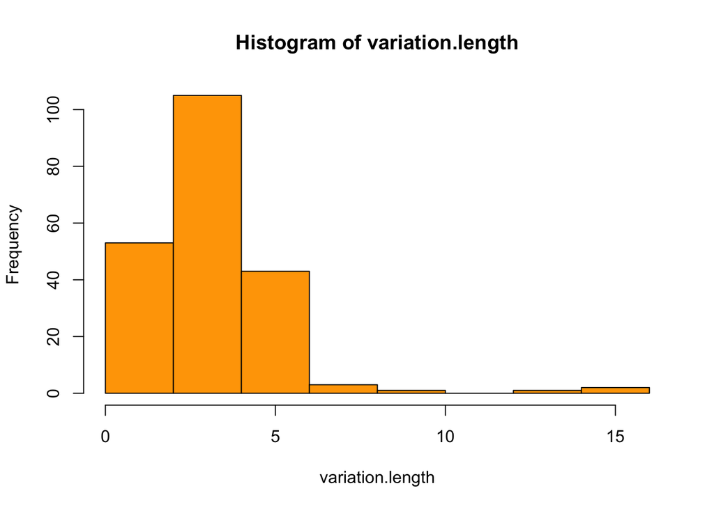

```r
hist(variation.length, col = c(rep("orange", 2)))
```

```r
F2Df_progress$invariance_max <- variation.length

# extract subject id who has more than 20 repetitive response in a row
id_invariance <- F2Df_progress$MTurkCode[variation.length > 10]
```

### F2 Data screening summary

There’s no overlap between subjects who had really short duration and how had a large number of repetitive response. So, at this stage I would not screening out any subjects based on these criteira, but I’m going to mark them in the summary sheet.

```r
# exclude participants who terminated all their goals at F1

F1_terminateSum = F1_terminateGoals %>%
  group_by(MTurkCode) %>%
  summarize(listNum = mean(listNum),
            terminateSum = sum(F1_terminate),
            terminatePerc = sum(F1_terminate)/listNum) # check the percentage of terminated goals at F1
F1_allTerminate <- F1_terminateSum$MTurkCode[F1_terminateSum$listNum == F1_terminateSum$terminateSum]

# select variables relevant to screening
F2_screenSum <- F2Df %>%
  rename(MTurkCode = workerId) %>%
  left_join(F2Df_progress[,c("MTurkCode", "invariance_max", "listNum")], by = "MTurkCode") %>%
  select(MTurkCode, listNum, starts_with("status_"),duration, invariance_max)

# sort by duration
F2_screenSum %>%
  arrange(duration) %>%
  head(10)
```

```
##         MTurkCode listNum status_F2_1 status_F2_2 status_F2_3 status_F2_4
## 1  A3LL096CAY5WHB       2
## 2   AMTTB8JUWRRM7       2   continued
## 3  A1CTUG0RUGCY48       1   continued
## 4   AHGDYNKOKJWFJ       3   continued               continued
## 5  A1D7IULWFI8PB1       3   continued   continued   continued
## 6   AM0QVBV8L6QCJ       2   continued   continued
## 7  A2NAKIXS3DVGAA       1   continued
## 8  A26UAJWMMNN351       3   continued               continued
## 9  A1ROEDVMTO9Y3X       2   continued   continued
## 10 A1B5SSGMTAQ9B5       2   continued   continued
##    status_F2_5  duration invariance_max
## 1              0.8666667              1
## 2              1.3000000              2
## 3              1.8000000              2
## 4              2.2500000              6
## 5              2.8333333              4
## 6              2.9166667              5
## 7              2.9333333              4
## 8              3.0666667              2
## 9              3.1166667              4
## 10             3.1833333              2
```

```r
# sort by invariance_max
F2_screenSum %>%
  arrange(desc(invariance_max)) %>%
  head(10)
```

```
##         MTurkCode listNum status_F2_1 status_F2_2 status_F2_3 status_F2_4
## 1  A255RBA8P0K0XV       5   continued   continued   continued   continued
## 2   AVKMFV9CZ0MLR       5   continued   continued   continued   continued
## 3  A1WQACYPLESVGL       5   continued   completed   continued
## 4  A1XUZFDVKP95VC       2   continued   completed
## 5  A38DHLB88V8DL8       4   continued   continued   continued   continued
## 6  A1ZT0TLZZTT47M       5   continued   continued   continued   continued
## 7   AAHZCL4LIPCBQ       3   continued   continued   continued
## 8   AHGDYNKOKJWFJ       3   continued               continued
## 9  A3HXM7BGH18FOW       3   continued   continued   continued
## 10 A1NVF1YLDLF563       3   continued   continued   continued
##    status_F2_5  duration invariance_max
## 1    continued  9.900000             16
## 2    continued  6.816667             15
## 3    continued 29.483333             13
## 4               8.766667             10
## 5              17.383333              8
## 6    continued 10.766667              8
## 7               6.550000              7
## 8               2.250000              6
## 9               7.116667              6
## 10              7.433333              6
```

```r
# flag participants who has duration < 5 or repetitive response > 10
F2_screenSum <- F2_screenSum %>%
  mutate(F2_screen_Flag = case_when(
    duration < 5 ~ TRUE,
    invariance_max > 10 ~ TRUE,
    TRUE ~ FALSE
  ),
  F2_include = case_when(
    is.na(listNum) == TRUE ~ FALSE, # would not include subject who were screened out at baseline
    MTurkCode %in% F1_allTerminate ~ FALSE, # would not include subject who has terminated all their goals at F1
    TRUE ~ TRUE
  ))
```

### Merge the summary data

```r
# merge summary data
summaryDf_F1 <- summaryDf %>%
  left_join(select(F1Df, c(starts_with("status_"), workerId, Finished)), by = c("MTurkCode" = "workerId")) %>%
  left_join(select(F1_screenSum, c(F1_screen_Flag, F1_include, MTurkCode)), by = "MTurkCode") %>%
  rename(F1_complete = Finished) %>%
  mutate(F1_complete = recode(F1_complete, `1` = TRUE)) %>%
  mutate(F1_complete = replace_na(F1_complete, FALSE))


# merge summary data
summaryDf_F2 <- summaryDf_F1 %>%
  left_join(select(F2Df, c(starts_with("status_"), workerId, Finished)), by = c("MTurkCode" = "workerId")) %>%
  left_join(select(F2_screenSum, c(F2_screen_Flag, F2_include, MTurkCode)), by = "MTurkCode") %>%
  rename(F2_complete = Finished) %>%
  mutate(F2_complete = recode(F2_complete, `1` = TRUE)) %>%
  mutate(F2_complete = replace_na(F2_complete, FALSE))
```

## Clean Follow-up 2 datasets:

A clean dataset for the progress ratings for goals continued from F1

```r
F2_progress_base <- F2Df_progress_long %>%
  rowwise() %>%
  mutate(variable = case_when( # cut the str represent goalID from variable name
    str_detect(variable, "ACRISS") ~ paste0(substr(variable, 1,9), substr(variable,12,13)),
    TRUE ~ str_sub(variable, 1, nchar(variable)-2))) %>%
  spread (variable, rating)
```

A goal representation dataset for goals that are achieved or abandoned.

```r
# filter out goals that are achieved or abandoned
F2_terminateGoals <- F2_progress_base %>%
  select(MTurkCode, goal, status_F2, listNum) %>%
  rename(status = status_F2) %>%
  filter(status == "completed" | status == "abandoned") %>%
  mutate(F2_terminate = TRUE,
         terminate_time = "F2")

# transform the goal rep dataset into a long format
F2_goalRep_long <- F2Df %>%
  select(workerId, starts_with("G")) %>%
  select(-starts_with("goal")) %>%
  pivot_longer(
    cols = starts_with("G"),
    names_to = c("variable", "time_point", "goal"),
    values_to = "rating",
    names_prefix = "G",
    names_sep = "_"
  ) %>%
  mutate(variable = as.numeric(variable)) %>%
  filter(variable < 32) %>%
  arrange(workerId, variable)# exclude variables corresponding to the progress rating for new goals

# replace the variable numbers with the variable names
variableName <- c("construal_level", "temporal_duration", "frequency", "specificity", "end_state_specificity", "approach_avoidance", "attainment_maintenance", "measurability", "importance", "meaningfulness", "instrumentality", "connectedness", "attractiveness_achievement", "attractiveness_progress", "social_desirability", "difficulty", "affordance", "attainability", "clarity", "control", "external_motivation", "introjected_motivation", "identified_motivation", "intrinsic_motivation", "ought_motivation", "ideal_motivation", "basic_needs", "commonality", "visibility", "external_importance", "conflict")

replaceName <- rep(rep(variableName, each = 5), length(unique(F2_goalRep_long$workerId))) # repeat the name list for all five goals for each subject

F2_goalRep_long$variable <- replaceName

# transform the goal rep dataset into a wide format
F2_goalRep_wide <- F2_goalRep_long %>%
  spread (variable, rating)

# merge with the terminated goal dataset
F2_goalRep_post_w <- F2_terminateGoals %>%
  left_join(F2_goalRep_wide, by = c("MTurkCode" = "workerId", "goal")) %>%
  select(-F2_terminate)

# transform the wide format into a long format
F2_goalRep_post_l <- F2_goalRep_post_w %>%
  gather(affordance: visibility, key = "variable", value = "post_rating")
```

A goal representation dataset for goals that are adjusted

```r
# filter out goals that are adjusted
F2_adjustGoals <- F2_progress_base %>%
  select(MTurkCode, goal, status_F2, listNum) %>%
  filter(status_F2 == "adjusted") %>%
  mutate(F2_adjust = TRUE)

# transform the goal rep dataset into a long format (including goal progress)
F2_goalRep_long_aj <- F2Df %>%
  select(workerId, starts_with("G")) %>%
  select(-starts_with("goal")) %>%
  pivot_longer(
    cols = starts_with("G"),
    names_to = c("variable", "time_point", "goal"),
    values_to = "rating",
    names_prefix = "G",
    names_sep = "_"
  ) %>%
  mutate(variable = as.numeric(variable)) %>%
  arrange(workerId, variable)

# add the variables pertaining to progress
variableName_progress <- c(variableName, c("commitment", "urgency", "effort", "initial_time", "regret", "procrastination", "failure", "self_resources", "other_resources", "implementation_intention"))

replaceName <- rep(rep(variableName_progress, each = 5), length(unique(F2_goalRep_long_aj$workerId))) # repeat the name list for all five goals for each subject

F2_goalRep_long_aj$variable <- replaceName

# transform the goal rep dataset into a wide format
F2_goalRep_wide_aj<- F2_goalRep_long_aj %>%
  spread (variable, rating)

# merge with the adjusted goal dataset
F2_goalRep_adjust_w <- F2_adjustGoals %>%
  left_join(F2_goalRep_wide_aj, by = c("MTurkCode" = "workerId", "goal")) %>%
  rename(status = status_F2)%>%
  select(-F2_adjust)

# transform the wide format into a long format
F2_goalRep_adjust_l <- F2_goalRep_adjust_w %>%
  gather(affordance: visibility, key = "variable", value = "adjustBase_rating")
```

## Merge F1 & F2 post-rating and adjusted baseline-rating

Merge terminated goals

```r
F12_terminateGoals <- F1_terminateGoals %>%
  bind_rows(F2_terminateGoals) %>%
  select(-F1_terminate, -F2_terminate) %>%
  mutate(terminated = TRUE)
```

Merge post-rating data

```r
# wide format
F12_goalRep_post_w <-
  F1_goalRep_post_w %>%
  bind_rows(F2_goalRep_post_w)

# long format
F12_goalRep_post_l <-
  F1_goalRep_post_l %>%
  bind_rows(F2_goalRep_post_l)
```

Merge adjusted baseline-rating

```r
# wide format
F12_goalRep_adjust_w <-
  F1_goalRep_adjust_w %>%
  bind_rows(F2_goalRep_adjust_w)

# long format
F12_goalRep_adjust_l <-
  F1_goalRep_adjust_l %>%
  bind_rows(F2_goalRep_adjust_l)
```

## Screen follow-up 3:

### exclude participants who terminated all their goals at either F1 or F2

3 participants terminated all their goals at F2. In total, 4 participants have terminated all their goals before F3.

```r
# exclude participants who terminated all their goals at F1
F2_terminateSum = F2_terminateGoals %>%
  group_by(MTurkCode) %>%
  summarize(listNum = mean(listNum),
            terminateSum = sum(F2_terminate),
            terminatePerc = sum(F2_terminate)/listNum) # check the percentage of terminated goals at F2
F2_allTerminate <- F2_terminateSum$MTurkCode[F2_terminateSum$listNum == F2_terminateSum$terminateSum]
F12_allTerminate <- c(F1_allTerminate, F2_allTerminate)
```

### Check duration:

```r
F3Df$duration <- F3Df$Duration..in.seconds./60

# check durations
describe(F3Df$duration)
```

```
##    vars   n  mean    sd median trimmed   mad  min    max  range skew kurtosis
## X1    1 217 23.56 18.32  19.67   20.55 12.01 1.03 134.28 133.25 2.38      8.2
##      se
## X1 1.24
```

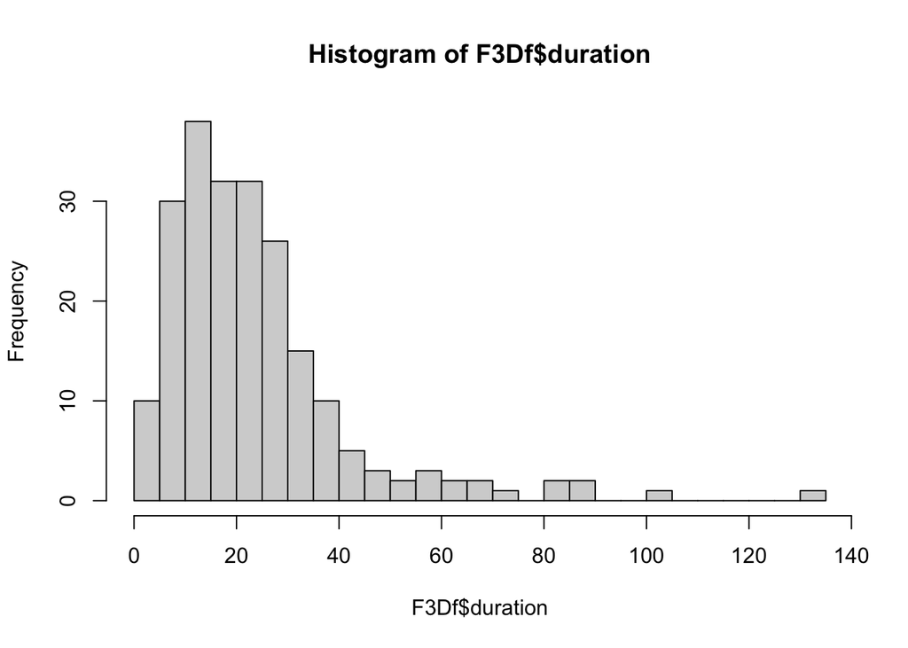

```r
hist(F3Df$duration, 20)
```

```r
# check subjects who completed within 5 minutes
durationDf <- summaryDf %>%
  left_join(F3Df, by = c("MTurkCode" = "workerId")) %>%
  select(MTurkCode, listNum, duration, contains("status_")) %>%
  filter(!MTurkCode %in% F12_allTerminate) %>% # filter out participants who terminated all their goals in previous follow-ups
  arrange(duration) %>%
  filter(duration < 5)

duration_id <- durationDf$MTurkCode
```

### check missing data

For goal progress ratings:

1 subject missed almost all the questions and will be excluded; among others, 3 missed 4 questions and the rest missed no more than 3.

```r
# select and modify variables only relevant to follow-up progress
F3Df_progress <- F3Df %>%
  left_join(select(baselineDf, MTurkCode, listNum, starts_with("goalType_")), by = c("workerId" = "MTurkCode")) %>%
  rename(MTurkCode = workerId) %>%
  filter(is.na(listNum) == FALSE) %>% # filter out subjects who didn't pass baseline screening
  filter(!MTurkCode %in% F12_allTerminate) %>% #filter out participants who terminated all their goals in previous follow-ups
  select(starts_with("status_"),starts_with("ACRISS"),starts_with("commitment"),starts_with("urgency"),starts_with("effort"),starts_with("AR"), # select goal progress relevant variables
        starts_with("resources"),starts_with("plan"),paste0("PA1_F3_", 1:5),paste0("PA3_F3_", 1:5),paste0("PB1_F3_", 1:5),paste0("PB3_F3_", 1:5),paste0("PC1_F3_", 1:5),paste0("PC3_F3_", 1:5), starts_with("goalType_"), MTurkCode, listNum) %>%
  select(-starts_with("goalType_F3")) %>%
  rowwise() %>%
  mutate(progress_F3_1 = case_when( # extract the corresponding progress and satisfaction ratings based on goal types
    goalType_1 == 1 ~ PA1_F3_1,
    goalType_1 == 2 ~ PB1_F3_1,
    goalType_1 == 3 ~ PC1_F3_1),
    progress_F3_2 = case_when(
    goalType_2 == 1 ~ PA1_F3_2,
    goalType_2 == 2 ~ PB1_F3_2,
    goalType_2 == 3 ~ PC1_F3_2),
    progress_F3_3 = case_when(
    goalType_3 == 1 ~ PA1_F3_3,
    goalType_3 == 2 ~ PB1_F3_3,
    goalType_3 == 3 ~ PC1_F3_3),
    progress_F3_4 = case_when(
    goalType_4 == 1 ~ PA1_F3_4,
    goalType_4 == 2 ~ PB1_F3_4,
    goalType_4 == 3 ~ PC1_F3_4),
    progress_F3_5 = case_when(
    goalType_5 == 1 ~ PA1_F3_5,
    goalType_5 == 2 ~ PB1_F3_5,
    goalType_5 == 3 ~ PC1_F3_5),
    satisfaction_F3_1 = case_when(
    goalType_1 == 1 ~ PA3_F3_1,
    goalType_1 == 2 ~ PB3_F3_1,
    goalType_1 == 3 ~ PC3_F3_1),
    satisfaction_F3_2 = case_when(
    goalType_2 == 1 ~ PA3_F3_2,
    goalType_2 == 2 ~ PB3_F3_2,
    goalType_2 == 3 ~ PC3_F3_2),
    satisfaction_F3_3 = case_when(
    goalType_3 == 1 ~ PA3_F3_3,
    goalType_3 == 2 ~ PB3_F3_3,
    goalType_3 == 3 ~ PC3_F3_3),
    satisfaction_F3_4 = case_when(
    goalType_4 == 1 ~ PA3_F3_4,
    goalType_4 == 2 ~ PB3_F3_4,
    goalType_4 == 3 ~ PC3_F3_4),
    satisfaction_F3_5 = case_when(
    goalType_5 == 1 ~ PA3_F3_5,
    goalType_5 == 2 ~ PB3_F3_5,
    goalType_5 == 3 ~ PC3_F3_5)
    ) %>%
  select(-paste0("PA1_F3_", 1:5),-paste0("PA3_F3_", 1:5),-paste0("PB1_F3_", 1:5),-paste0("PB3_F3_", 1:5),-paste0("PC1_F3_", 1:5),-paste0("PC3_F3_", 1:5))

# transform the progress rating df into a long format
F3Df_progress_long <- F3Df_progress %>%
  gather(variable, rating, c(status_F3_1: plan_F3_5, goalType_1: goalType_5, progress_F3_1: satisfaction_F3_5)) %>%
  rowwise() %>%
  mutate(goal = case_when( # generated the corresponding goal number from the variable name
    str_detect(variable, "goalType") ~ str_split_fixed(variable, "_", n = 4)[2],
    str_detect(variable, "resources") ~ str_split_fixed(variable, "_", n = 4)[4],
    TRUE ~ str_split_fixed(variable, "_", n = 4)[3])) %>%
  filter(goal <= listNum) %>% # only include the ratings corresponding to the goals they listed at baseline
  left_join(select(F12_terminateGoals, MTurkCode, goal, terminated), by = c("MTurkCode", "goal")) %>%
  filter(is.na(terminated) == TRUE) # only include the ratings corresponding to goals that haven't been terminated at F1

F3_progress_base <- F3Df_progress_long %>%
  rowwise() %>%
  mutate(variable = case_when( # cut the str represent goalID from variable name
    str_detect(variable, "ACRISS") ~ paste0(substr(variable, 1,9), substr(variable,12,13)),
    TRUE ~ str_sub(variable, 1, nchar(variable)-2))) %>%
  spread (variable, rating)

# calculate the percentage of missing data
F3Df_progress_sum <- F3Df_progress_long %>%
  group_by(MTurkCode) %>%
  summarise(missNum = sum(is.na(rating)),
            totalNum = mean(listNum) * 17,
            missPerc = ((missNum/totalNum) * 100)) %>%
  arrange(desc(missPerc))
missing_id <- F3Df_progress_sum$MTurkCode[1]
```

For goal post-representation ratings:

Other than the person who has been screen out for the progress rating, no participants have missed more than 3 questions

```r
# transform the goal rep dataset into a long format
F3_goalRep_long <- F3Df %>%
  left_join(select(baselineDf, MTurkCode, listNum), by = c("workerId" = "MTurkCode")) %>%
  rename(MTurkCode = workerId) %>%
  select(MTurkCode, starts_with("G"), listNum) %>%
  select(-starts_with("goal")) %>%
  pivot_longer(
    cols = starts_with("G"),
    names_to = c("variable", "time_point", "goal"),
    values_to = "rating",
    names_prefix = "G",
    names_sep = "_"
  ) %>%
  mutate(variable = as.numeric(variable)) %>%
  filter(variable < 32) %>% # exclude variables corresponding to the progress rating for new goals
  filter(!str_detect(goal, "N")) %>%
  arrange(MTurkCode, variable)

# replace the variable numbers with the variable names
variableName <- c("construal_level", "temporal_duration", "frequency", "specificity", "end_state_specificity", "approach_avoidance", "attainment_maintenance", "measurability", "importance", "meaningfulness", "instrumentality", "connectedness", "attractiveness_achievement", "attractiveness_progress", "social_desirability", "difficulty", "affordance", "attainability", "clarity", "control", "external_motivation", "introjected_motivation", "identified_motivation", "intrinsic_motivation", "ought_motivation", "ideal_motivation", "basic_needs", "commonality", "visibility", "external_importance", "conflict")

replaceName <- rep(rep(variableName, each = 5), length(unique(F3_goalRep_long$MTurkCode))) # repeat the name list for all five goals for each subject

F3_goalRep_long$variable <- replaceName

# transform the goal rep dataset into a wide format
F3_goalRep_post_w <- F3_goalRep_long %>%
  filter(goal <= listNum) %>% # only include the ratings corresponding to the goals they listed at baseline
  left_join(select(F12_terminateGoals, MTurkCode, goal, terminated), by = c("MTurkCode", "goal")) %>%
  filter(is.na(terminated) == TRUE) %>% # only include the ratings corresponding to goals that haven't been terminated at F1
  spread (variable, rating) %>%
  select(-terminated)

# transform the wide format into a long format
F3_goalRep_post_l <- F3_goalRep_post_w %>%
  gather(affordance: visibility, key = "variable", value = "post_rating")

# calculate the percentage of missing data
F3_goalRep_post_l %>%
  group_by(MTurkCode) %>%
  summarise(missNum = sum(is.na(post_rating)),
            totalNum = mean(listNum) * 31,
            missPerc = ((missNum/totalNum) * 100)) %>%
  arrange(desc(missPerc))
```

```
## # A tibble: 211 x 4
##    MTurkCode      missNum totalNum missPerc
##    <chr>            <int>    <dbl>    <dbl>
##  1 AYPOAY43REHC8      155      155   100
##  2 A2PE32I58ANCDD       3       62     4.84
##  3 A1EH9BPKYXFBS5       2      155     1.29
##  4 A33RI08QRVG5Q0       2      155     1.29
##  5 A132GRVDGXPJGY       1       93     1.08
##  6 A1LS7GARU7CD08       1       93     1.08
##  7 A1TPGXT718D68E       1       93     1.08
##  8 A286W816CMIZL9       1       93     1.08
##  9 A2X3FSFHV5GHJU       1       93     1.08
## 10 AF0W4ZBY7VXOU        1       93     1.08
## # … with 201 more rows
```

### check repetitive response

12 participants had repetitive response for more than 20 questions in a row (the criteria at baseline); The max is 38

```r
# extract columns with self-report ratings
F3Df_rating <- F3_progress_base %>%
  select(-c("listNum","status_F3", "terminated", "goalType")) %>%
  left_join(F3_goalRep_post_w, by = c("MTurkCode", "goal")) %>%
  select(-time_point)

# extract the max number of repetitive response in a row
variation <- apply(F3Df_rating,1,function(x) rle(x))
variation.length <-unlist(lapply(variation,function(x) max(x$lengths)))
#describe(variation.length)
#hist(variation.length, col = c(rep("orange", 2)))
F3Df_rating$invariance_max <- variation.length

# transform to subject level summary data
F3Df_rating_sum <- F3Df_rating %>%
  group_by(MTurkCode) %>%
  summarise(invariance_sum = sum(invariance_max),
            listNum = mean(listNum))
describe(F3Df_rating_sum$invariance_sum)
```

```
##    vars   n  mean   sd median trimmed  mad min max range skew kurtosis  se
## X1    1 211 10.89 5.74     10   10.37 5.93   2  38    36 1.06     1.95 0.4
```

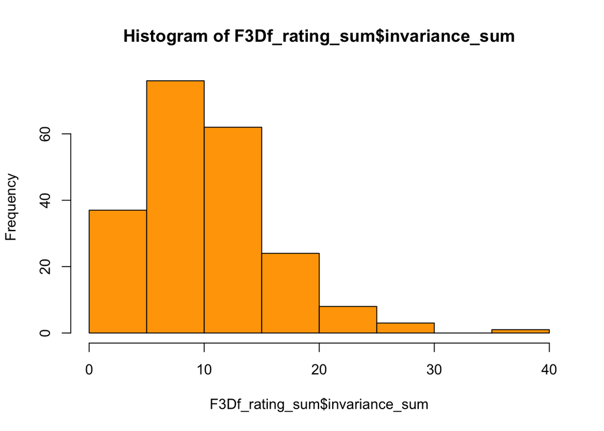

```r
hist(F3Df_rating_sum$invariance_sum, col = c(rep("orange", 2)))
```

```r
# extract IDs who have repetitive response > 20
invariance_id <- F3Df_rating_sum$MTurkCode[F3Df_rating_sum$invariance_sum > 20]
```

### F3 Data screening summary

There’s no overlap between subjects who had really short duration and how had a large number of repetitive response. So, at this stage I would not screening out any subjects based on these criteira, but I’m going to mark them in the summary sheet. Out of the 217 subjects who submitted their F3 survey, I’ve excluded 2 subjects how were screened out at baseline, 4 subjects who have terminated all their goals at F1 or F2 and 1 subjects who missed almost all the questions

```r
# select variables relevant to screening
F3_screenSum <- F3Df %>%
  select(starts_with("status_"),duration, workerId) %>%
  left_join(F3Df_rating_sum, by = c("workerId" = "MTurkCode")) %>%
  rename(MTurkCode = workerId) %>%
  select(MTurkCode, listNum, starts_with("status_"),duration, invariance_sum)

# sort by duration
F3_screenSum %>%
  arrange(duration) %>%
  head(10)
```

```
##         MTurkCode listNum status_F3_1 status_F3_2 status_F3_3 status_F3_4
## 1  A1G187YBG0DVMQ      NA
## 2   AT6LDQNLKTUSE      NA
## 3  A3UUH3632AI3ZX      NA
## 4  A1J8TVICSRC70W      NA
## 5   AMTTB8JUWRRM7       2   continued
## 6  A1CTUG0RUGCY48       1   continued
## 7  A1WJYF201K77BI       5                           abandoned
## 8  A34VLM2UC0JY11       2               completed
## 9   A1KC342L9WAQ2       3                           continued
## 10 A2NAKIXS3DVGAA       1   continued
##    status_F3_5 duration invariance_sum
## 1              1.033333             NA
## 2              1.166667             NA
## 3              1.700000             NA
## 4              2.233333             NA
## 5              3.866667              4
## 6              4.066667              2
## 7              4.416667              4
## 8              4.633333              5
## 9              4.650000              3
## 10             4.750000              5
```

```r
# sort by invariance_sum
F3_screenSum %>%
  arrange(desc(invariance_sum)) %>%
  head(10)
```

```
##         MTurkCode listNum status_F3_1 status_F3_2 status_F3_3 status_F3_4
## 1   AHKRGPN5D3I2G       5   continued   completed               continued
## 2  A2IJEKMVEHQ90W       5   continued   completed   continued   continued
## 3  A1U8LTCX5XYJ45       3   continued   continued   continued
## 4  A255RBA8P0K0XV       5   continued   continued   continued   continued
## 5   AXF0OX50YZQC6       5   continued   continued   continued   completed
## 6   AVKMFV9CZ0MLR       5    adjusted    adjusted   continued   continued
## 7  A3AE0JEXW4DB34       5   continued   continued   continued   continued
## 8  A1W850QN9RK019       5   continued   completed   continued   continued
## 9  A13O22EMG5ZVN0       3   continued   continued   continued
## 10 A1ABL45KAK12A5       5   continued               continued   continued
##    status_F3_5 duration invariance_sum
## 1    continued 34.45000             38
## 2              22.90000             29
## 3              10.08333             27
## 4    continued 38.00000             26
## 5    continued 41.53333             25
## 6    continued 29.08333             25
## 7    abandoned 28.06667             23
## 8    completed 64.96667             23
## 9              10.25000             22
## 10   continued 28.35000             22
```

```r
# flag participants who has duration < 5 and exclude the subject who has missed almost all the questions
F3_screenSum <- F3_screenSum %>%
  mutate(F3_duration_flag = case_when(
    duration < 5 ~ TRUE,
    TRUE ~ FALSE),
    F3_invariance_flag = case_when(
    invariance_sum > 20 ~ TRUE,
    TRUE ~ FALSE)) %>%
  rowwise() %>%
  mutate(F3_flag_sum = sum(F3_duration_flag + F3_invariance_flag)) %>%
  mutate(F3_include = case_when(
    is.na(listNum) == TRUE ~ FALSE, # would not include subject who were screened out at baseline
    MTurkCode %in% F12_allTerminate ~ FALSE, # would not include subject who has terminated all their goals at F1 or F2
    MTurkCode %in% missing_id ~ FALSE, # would not include the subject who missed almost all the questions
    TRUE ~ TRUE
  ))
```

### Merge summary data

```r
# merge summary data
merged_summaryDf <- summaryDf_F2 %>%
  left_join(select(F3Df, c(starts_with("status_"), workerId, Finished)), by = c("MTurkCode" = "workerId")) %>%
  left_join(select(F3_screenSum, c(F3_duration_flag, F3_invariance_flag, F3_flag_sum, F3_include, MTurkCode)), by = "MTurkCode") %>%
  rename(F3_complete = Finished) %>%
  mutate(F3_complete = recode(F3_complete, `1` = TRUE)) %>%
  mutate(F3_complete = replace_na(F3_complete, FALSE))
```

## Clean Follow-up 3 datasets:

A dataset for the goal representation ratings for adjusted goals

```r
# filter out goals that are adjusted
F3_adjustGoals <- F3_progress_base %>%
  select(MTurkCode, goal, status_F3, listNum) %>%
  filter(status_F3 == "adjusted") %>%
  mutate(F3_adjust = TRUE)

# transform the goal rep dataset into a long format (including goal progress)
F3_goalRep_long_aj <- F3Df %>%
  select(workerId, starts_with("G")) %>%
  select(-starts_with("goal")) %>%
  pivot_longer(
    cols = starts_with("G"),
    names_to = c("variable", "time_point", "goal"),
    values_to = "rating",
    names_prefix = "G",
    names_sep = "_"
  ) %>%
  mutate(variable = as.numeric(variable)) %>%
  arrange(workerId, variable) %>%
  filter(str_detect(goal, "N") | variable > 31) %>%
  mutate(goal = case_when(str_detect(goal, "N") ~ str_sub(goal, 1, nchar(goal)-1),
                          TRUE ~ goal))

# add the variables pertaining to progress
variableName_progress <- c(variableName, c("commitment", "urgency", "effort", "initial_time", "regret", "procrastination", "failure", "self_resources", "other_resources", "implementation_intention"))

replaceName <- rep(rep(variableName_progress, each = 5), length(unique(F3_goalRep_long_aj$workerId))) # repeat the name list for all five goals for each subject

F3_goalRep_long_aj$variable <- replaceName

# transform the goal rep dataset into a wide format
F3_goalRep_wide_aj<- F3_goalRep_long_aj %>%
  spread (variable, rating)

# merge with the adjusted goal dataset
F3_goalRep_adjust_w <- F3_adjustGoals %>%
  left_join(F3_goalRep_wide_aj, by = c("MTurkCode" = "workerId", "goal")) %>%
  rename(status = status_F3)%>%
  select(-F3_adjust)

# transform the wide format into a long format
F3_goalRep_adjust_l <- F3_goalRep_adjust_w %>%
  gather(affordance: visibility, key = "variable", value = "adjustBase_rating")
```

## Merge post-rating and adjusted base-rating datasets

Merge post-rating data:

756 goals were included in the post-rating datasets (including the ones that were achieved or abandoned at F1 or F2)

```r
# transform status data to goal level wide format
F3_status <- F3Df %>%
  select(workerId, starts_with("status_")) %>%
  gather(status_F3_1: status_F3_5, key = "goal", value = "status") %>%
  rowwise() %>%
  mutate(goal = str_sub(goal, 11,11))

# add status to the post-rating wide df
F3_goalRep_post_w <- F3_goalRep_post_w %>%
  left_join(select(F3_status, workerId, goal, status), by = c("MTurkCode" = "workerId", "goal" = "goal"))

# merge with F1 & F2 post-rating wide df
merged_goalRep_post_w <- F12_goalRep_post_w %>%
  bind_rows(F3_goalRep_post_w)

F3_goalRep_post_l <- F3_goalRep_post_w %>%
  gather(affordance: visibility, key = "variable", value = "post_rating")

# long format
merged_goalRep_post_l <- F12_goalRep_post_l %>%
  bind_rows(F3_goalRep_post_l)
```

Merge adjusted baseline-rating:

86 goals were adjusted and their “baseline” goal representation data is included in these two datasets

```r
# wide format
merged_goalRep_adjust_w <-
  F12_goalRep_adjust_w %>%
  bind_rows(F3_goalRep_adjust_w)

# long format
merged_goalRep_adjust_l <-
  F12_goalRep_adjust_l %>%
  bind_rows(F3_goalRep_adjust_l)
```

# Data Summary

## Subject Level:

retention rate:  
252 subjects completed the baseline survey and 246 were included in the analysis (inclusion rate: 97.6%); The retention rates of three follow-up surveys respectively are : 90.7%; 84.6% and 88.2%. 78.9% of the participants were included in all four surveys.

```r
merged_summaryDf_subject <- merged_summaryDf %>%
  rowwise() %>%
  mutate(complete_num = baseline_complete + F1_complete + F2_complete + F3_complete,
         included_num = baseline_complete + F1_include + F2_include + F3_include) %>%
  ungroup() %>%
  summarise(baseline_includeRate = sum(baseline_complete, na.rm = T) / 252,
            F1_retentionRate = sum(F1_complete, na.rm = T) / sum(baseline_complete),
            F1_includeRate = sum(F1_include, na.rm = T) / sum(baseline_complete),
            F2_retentionRate = sum(F2_complete, na.rm = T) / sum(baseline_complete),
            F2_includeRate = sum(F2_include, na.rm = T) / sum(baseline_complete),
            F3_retentionRate = sum(F3_complete, na.rm = T) / sum(baseline_complete),
            F3_includeRate = sum(F3_include, na.rm = T) / sum(baseline_complete),
            complete_rate = sum(included_num == 4, na.rm = T) / sum(baseline_complete))

merged_summaryDf_subject%>%
  kable(format = "html", escape = F) %>%
  kable_styling(bootstrap_options = c("striped", "hover", "condensed"), full_width = F,position = "center")
```

| baseline_includeRate | F1_retentionRate | F1_includeRate | F2_retentionRate | F2_includeRate | F3_retentionRate | F3_includeRate | complete_rate |
| --- | --- | --- | --- | --- | --- | --- | --- |
| 0.9761905 | 0.9065041 | 0.8943089 | 0.8455285 | 0.8414634 | 0.8821138 | 0.8536585 | 0.7886179 |

## Goal level:

845 goals were listed at baseline

```r
merged_goalType_l <- merged_summaryDf %>%
  gather(goalType_1: goalType_5, key = "goal", value = "goalType") %>%
  rowwise() %>%
  mutate(goal = str_sub(goal, 10,10)) %>%
  filter(baseline_complete == TRUE & goal <= listNum)

merged_F1_status_l <- merged_summaryDf %>%
  gather(status_F1_1: status_F1_5, key = "goal", value = "F1_status") %>%
  rowwise() %>%
  mutate(goal = str_sub(goal, 11,11)) %>%
  filter(F1_include == TRUE & goal <= listNum)

merged_F2_status_l <- merged_summaryDf %>%
  gather(status_F2_1: status_F2_5, key = "goal", value = "F2_status") %>%
  rowwise() %>%
  mutate(goal = str_sub(goal, 11,11)) %>%
  filter(F2_include == TRUE & goal <= listNum)

merged_F3_status_l <- merged_summaryDf %>%
  gather(status_F3_1: status_F3_5, key = "goal", value = "F3_status") %>%
  rowwise() %>%
  mutate(goal = str_sub(goal, 11,11)) %>%
  filter(F3_include == TRUE & goal <= listNum)

merged_summaryDf_goal <- merged_goalType_l %>%
  left_join(select(merged_F1_status_l, MTurkCode, goal, F1_status), by = c("MTurkCode", "goal")) %>%
  left_join(select(merged_F2_status_l, MTurkCode, goal, F2_status), by = c("MTurkCode", "goal")) %>%
  left_join(select(merged_F3_status_l, MTurkCode, goal, F3_status), by = c("MTurkCode", "goal")) %>%
  select(MTurkCode, baseline_complete, listNum, goal, goalType, F1_include, F1_status, F2_include, F2_status, F3_include, F3_status)

# summarize by each goal type
merged_summaryDf_goal %>%
  group_by(goalType) %>%
  summarise(total_goal = n(),
            F1_continued = sum(F1_status =="continued", na.rm = T),
            F1_completed = sum(F1_status =="completed", na.rm = T),
            F1_abandoned = sum(F1_status =="abandoned", na.rm = T),
            F1_adjusted = sum(F1_status =="adjusted", na.rm = T),
            F2_continued = sum(F2_status =="continued", na.rm = T),
            F2_completed = sum(F2_status =="completed", na.rm = T),
            F2_abandoned = sum(F2_status =="abandoned", na.rm = T),
            F2_adjusted = sum(F2_status =="adjusted", na.rm = T),
            F3_continued = sum(F3_status =="continued", na.rm = T),
            F3_completed = sum(F3_status =="completed", na.rm = T),
            F3_abandoned = sum(F3_status =="abandoned", na.rm = T),
            F3_adjusted = sum(F3_status =="adjusted", na.rm = T)) %>%
  adorn_totals("row") %>%
  kable(format = "html", escape = F) %>%
  kable_styling(bootstrap_options = c("striped", "hover", "condensed"), full_width = F,position = "center")
```

| goalType | total_goal | F1_continued | F1_completed | F1_abandoned | F1_adjusted | F2_continued | F2_completed | F2_abandoned | F2_adjusted | F3_continued | F3_completed | F3_abandoned | F3_adjusted |
| --- | --- | --- | --- | --- | --- | --- | --- | --- | --- | --- | --- | --- | --- |
| long-term | 210 | 170 | 6 | 5 | 6 | 143 | 7 | 9 | 4 | 140 | 11 | 4 | 8 |
| recurrance | 377 | 295 | 12 | 15 | 10 | 261 | 9 | 9 | 15 | 241 | 17 | 15 | 14 |
| short-term | 258 | 195 | 30 | 5 | 4 | 129 | 33 | 10 | 12 | 95 | 33 | 10 | 13 |
| Total | 845 | 660 | 48 | 25 | 20 | 533 | 49 | 28 | 31 | 476 | 61 | 29 | 35 |